# proj_1

Sabrina Zhang

2026-04-19

```r
library(pacman)
p_load(tidyverse, scales, patchwork, fixest, here,glue)

income = here("~/Desktop/School Stuff/EC 421/pset_1/data-ps0.csv") |> read_csv()
```

## 2.

```r
# Dimensions of Data set
counties = distinct(select(income, county_name))

glue("Rows in Dataset: ", nrow(income), "| Columns in Dataset: ", ncol(income), "\n",
     "Number of Counties: ", count(counties))
```

```
## Rows in Dataset: 3106| Columns in Dataset: 18
## Number of Counties: list(n = 1051)
```

```r
head(income)
```

```
## # A tibble: 6 × 18
##   county_name county_code state_abb income_quartile life_exp pct_uninsured
##   <chr>             <dbl> <chr>               <dbl>    <dbl>         <dbl>
## 1 Autauga            1001 AL                      1     76.4         0.136
## 2 Autauga            1001 AL                      4     84.2         0.136
## 3 Baldwin            1003 AL                      1     79.5         0.191
## 4 Baldwin            1003 AL                      4     86.3         0.191
## 5 Barbour            1005 AL                      1     79.7         0.185
## 6 Barbour            1005 AL                      4     86.7         0.185
## # ℹ 12 more variables: poverty_rate <dbl>, pct_religious <dbl>,
## #   pct_black <dbl>, pct_hispanic <dbl>, unemployment_rate <dbl>,
## #   median_hh_inc <dbl>, is_urban <dbl>, pop <dbl>, pop_density <dbl>,
## #   pct_smoke <dbl>, pct_obese <dbl>, pct_exercise <dbl>
```

## 4.

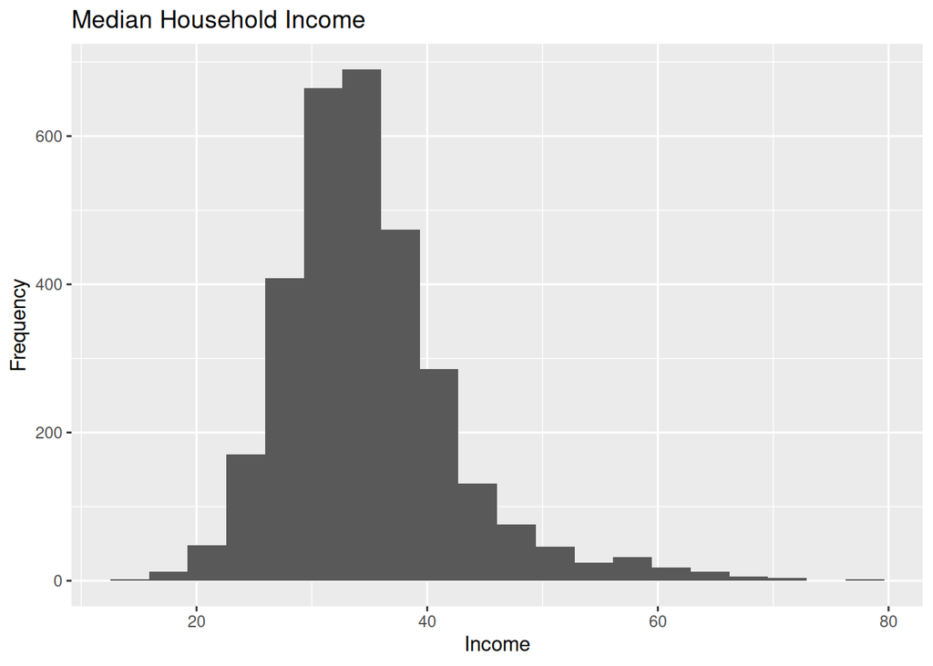

```r
ggplot(income, aes(x = median_hh_inc)) +
  geom_histogram(bins = 20) +
  labs(

    title = "Median Household Income",
    x = "Income",
    y = "Frequency",

  )
```

```r
  scale_x_continuous(labels = scales::dollar_format(scale = 1000))
```

```
## <ScaleContinuousPosition>
##  Range:
##  Limits:    0 --    1
```

### Creating Histograms

```r
create_histogram = function(df, column, color, title, x_title) {
  ggplot()+
  geom_histogram(data = df,
                 aes(x = {{column}}),
                 bins = 50, fill = color, alpha= 0.5)+
                 labs(title = title,
                      x = x_title,
                      y = "Frequency")

  }
```

## 5.

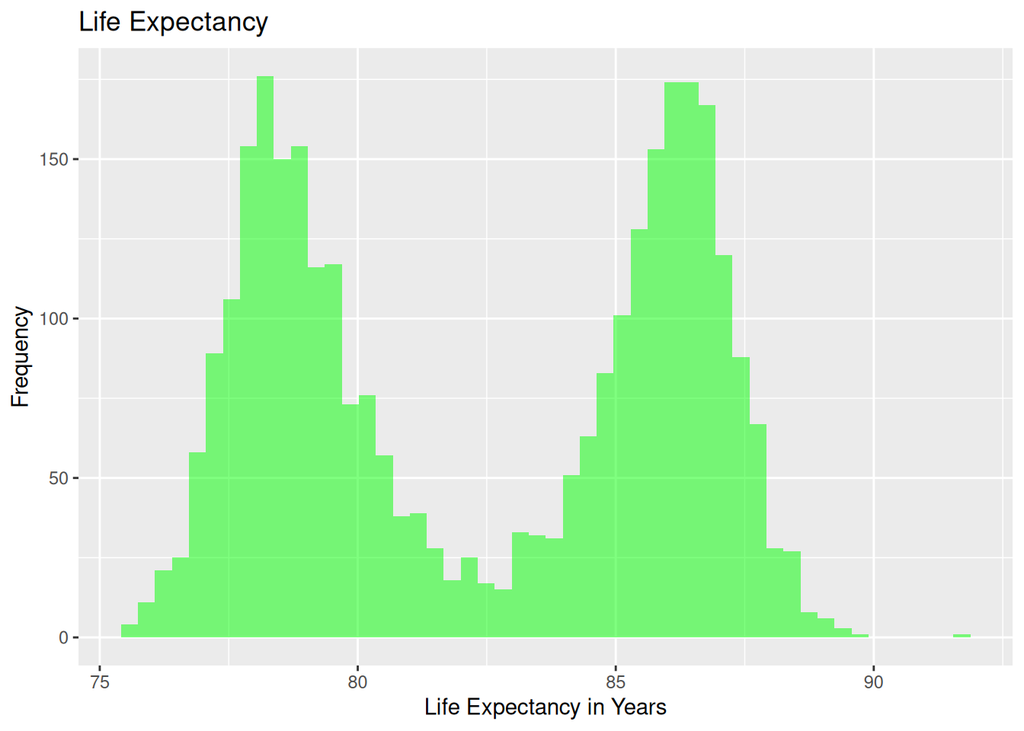

```r
create_histogram(income, life_exp, "green", "Life Expectancy", "Life Expectancy in Years")
```

## 7. Life Expectancy Q1 vs Q4

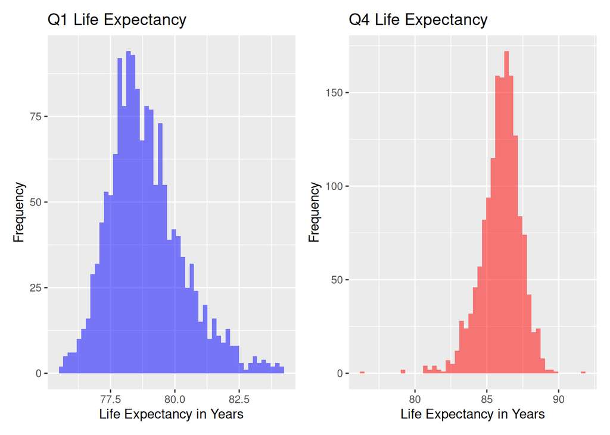

```r
life_exp_q1 = filter(income, income_quartile == 1)

life_exp_q4 = filter(income, income_quartile == 4)

q1_life_exp = create_histogram(life_exp_q1, life_exp, "blue", "Q1 Life Expectancy", "Life Expectancy in Years")
q4_life_exp = create_histogram(life_exp_q4, life_exp, "red", "Q4 Life Expectancy", "Life Expectancy in Years")

q1_life_exp + q4_life_exp
```

```r
##Average Life Expectancy in Q1:
mean(life_exp_q1$life_exp)
```

```
## [1] 78.86673
```

```r
##Average Life Expectancy in Q4:
mean(life_exp_q4$life_exp)
```

```
## [1] 85.97455
```

# 8.

```r
#create_histogram
# select county code and income quartile
life_exp_q1s = select(filter(income, income_quartile == 1), state_abb, county_name, county_code, life_exp)
life_exp_q4s = select(filter(income, income_quartile == 4), county_code, life_exp, )

# rename
names(life_exp_q1s)[names(life_exp_q1s) == "life_exp"] = "life_exp_q1"
names(life_exp_q4s)[names(life_exp_q4s) == "life_exp"] = "life_exp_q4"

# merge data
merged_data = full_join(life_exp_q1s, life_exp_q4s, by = "county_code")

merged_data$life_exp_diff = merged_data$life_exp_q4 - merged_data$life_exp_q1

diff_life_exp = create_histogram(merged_data, life_exp_diff, "green", "Life Exp Diff: Income Level Q1 vs Q4", "Life Expectancy in Years" )
```

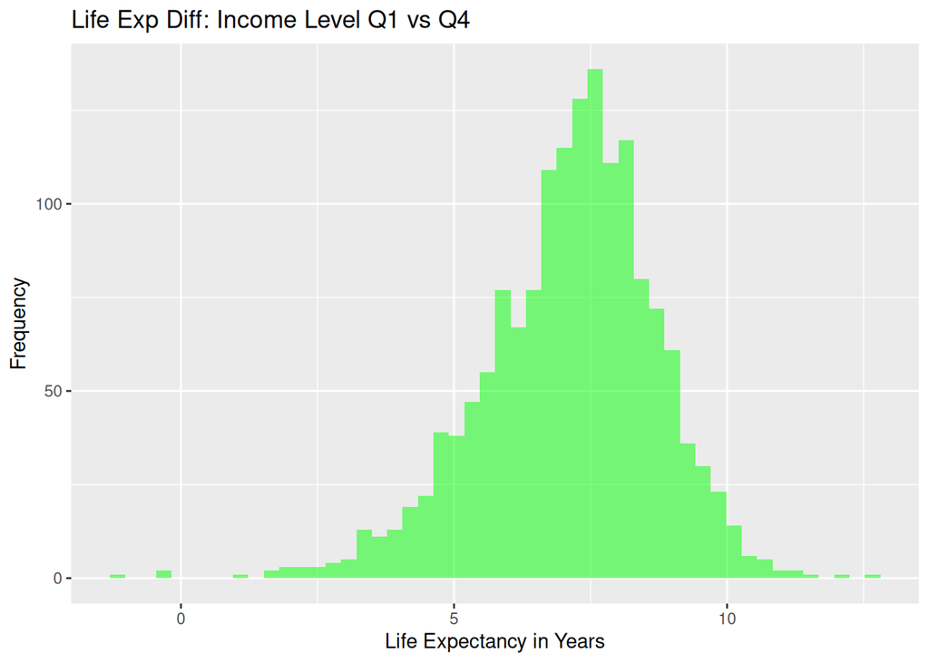

```r
diff_life_exp
```

```r
# Avg life Expectancy in Q1:

mean(life_exp_q1$life_exp)
```

```
## [1] 78.86673
```

```r
# Avg life Expectancy in Q4:
mean(life_exp_q4$life_exp)
```

```
## [1] 85.97455
```

```r
# Avg Diff. in Life Expectancy:
mean(merged_data$life_exp_diff,  na.rm = TRUE)
```

```
## [1] 7.107619
```

```r
# Lowest Diff. in Life Expectancy

min_life_diff = merged_data %>%
  filter(life_exp_diff == (min(merged_data$life_exp_diff, na.rm = TRUE)))

max_life_diff = merged_data %>%
  filter(life_exp_diff == (max(merged_data$life_exp_diff, na.rm = TRUE)))


min_life_diff
```

```
## # A tibble: 1 × 6
##   state_abb county_name county_code life_exp_q1 life_exp_q4 life_exp_diff
##   <chr>     <chr>             <dbl>       <dbl>       <dbl>         <dbl>
## 1 KY        Knox              21121        77.5        76.3         -1.16
```

```r
max_life_diff
```

```
## # A tibble: 1 × 6
##   state_abb county_name county_code life_exp_q1 life_exp_q4 life_exp_diff
##   <chr>     <chr>             <dbl>       <dbl>       <dbl>         <dbl>
## 1 KY        Bell              21013        79.0        91.7          12.7
```

## 9. Histogram Findings:

The life expectancy in the first quartile income level clusters around 77 to 80 years old whereas for Q4, the life expectancy clusters around 85 to about 87 years old. Taking the average of each quartile, we see that:

- A person within the first quartile of income has an average life expectancy of 79 years old.
- A person in the fourth quartile of income has an average life expectancy of 86 years old.
- The average difference in life expectancy for all counties is about 7 years.
- The distribution of difference in life expectancy is roughly normal.
- The population in Q1 has more spread than the population in Q4, which is more concentrated at ~87 years old.
- Both have a roughly normal distribution however it can be observed that Q1 has a slight right skew.

The majority of difference in life expectancy clusters between 5 to 10 years, with many around counties frequently recorded at 7 years in discrepancy.

## 10. Relationship Between income and Life expectancy

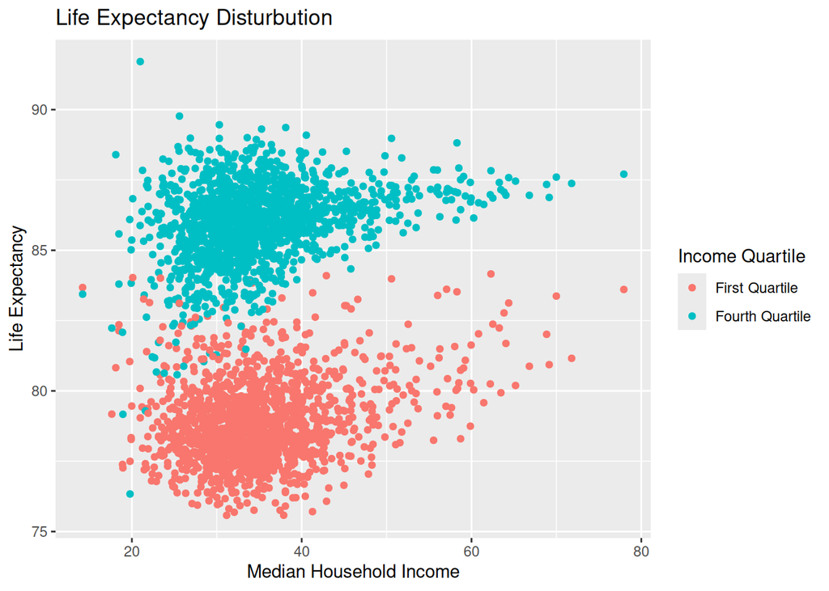

```r
ggplot(data= income) + geom_point(aes(x = median_hh_inc,
                                      y = life_exp,
                                      color = factor(
                                        income_quartile,
                                        labels = c("First Quartile", "Fourth Quartile")))) +
  labs(title = "Life Expectancy Disturbution",
    x = "Median Household Income",
    y = "Life Expectancy",
    color = "Income Quartile"
   )
```

## 11.

The relationship between life expectancy and median household income shows that the population of the counties that earn within the 4th quartile of income will, on average, live longer than those in the 1st quartile. For both Q1 and Q4 income earners, there is a positive relationship between median household income and life expectancy. However at similar income levels, the Q1 earners live shorter lives than those who earn the same amount in the Q4, suggesting that quality of life may depend on other factors to determine life expectancy.

## 12. Regressing on the data in general

```r
income_life_exp = lm(life_exp ~ median_hh_inc, data = income)

summary(income_life_exp)
```

```
##
## Call:
## lm(formula = life_exp ~ median_hh_inc, data = income)
##
## Residuals:
##     Min      1Q  Median      3Q     Max
## -7.0454 -3.7338  0.3938  3.5828 10.0043
##
## Coefficients:
##                Estimate Std. Error t value Pr(>|t|)
## (Intercept)   80.618136   0.321070 251.092  < 2e-16 ***
## median_hh_inc  0.051742   0.009006   5.745 1.01e-08 ***
## ---
## Signif. codes:  0 '***' 0.001 '**' 0.01 '*' 0.05 '.' 0.1 ' ' 1
##
## Residual standard error: 3.804 on 3104 degrees of freedom
## Multiple R-squared:  0.01052,    Adjusted R-squared:  0.0102
## F-statistic: 33.01 on 1 and 3104 DF,  p-value: 1.006e-08
```

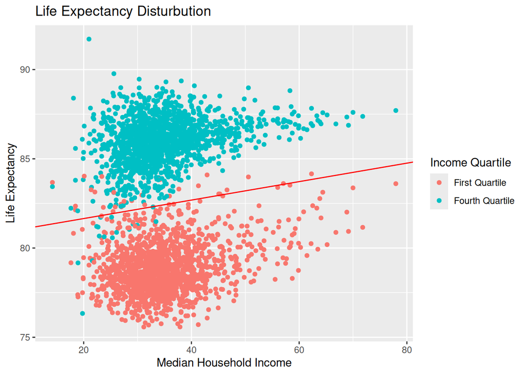

```r
ggplot(data= income) + geom_point(aes(x = median_hh_inc,
                                      y = life_exp,
                                      color = factor(
                                        income_quartile,
                                        labels = c("First Quartile", "Fourth Quartile")))) +
  labs(title = "Life Expectancy Disturbution",
    x = "Median Household Income",
    y = "Life Expectancy",
    color = "Income Quartile"
   ) +geom_abline(slope = 0.051742, intercept = 80.618136, color = "red")
```

## 13. The predicted life expectancy of a person with 0 income is 80.6 years old and per $1000 increase in income, there is a increase in life expectancy of 0.05 years.

## 14. Regression on Q1 and Q4

```r
income_q1 = lm(life_exp ~ median_hh_inc, data = (filter(income, income_quartile == 1)))

income_q4 = lm(life_exp ~ median_hh_inc, data = (filter(income, income_quartile == 4)))

#Q1 Data:
summary(income_q1)
```

```
##
## Call:
## lm(formula = life_exp ~ median_hh_inc, data = (filter(income,
##     income_quartile == 1)))
##
## Residuals:
##     Min      1Q  Median      3Q     Max
## -3.4605 -0.9394 -0.1774  0.7892  5.8531
##
## Coefficients:
##                Estimate Std. Error t value Pr(>|t|)
## (Intercept)   77.232936   0.168075 459.513   <2e-16 ***
## median_hh_inc  0.046904   0.004715   9.948   <2e-16 ***
## ---
## Signif. codes:  0 '***' 0.001 '**' 0.01 '*' 0.05 '.' 0.1 ' ' 1
##
## Residual standard error: 1.408 on 1551 degrees of freedom
## Multiple R-squared:  0.05998,    Adjusted R-squared:  0.05937
## F-statistic: 98.96 on 1 and 1551 DF,  p-value: < 2.2e-16
```

```r
#Q2 Data:
summary(income_q4)
```

```
##
## Call:
## lm(formula = life_exp ~ median_hh_inc, data = (filter(income,
##     income_quartile == 4)))
##
## Residuals:
##     Min      1Q  Median      3Q     Max
## -8.7940 -0.7109  0.0199  0.8085  6.5114
##
## Coefficients:
##                Estimate Std. Error t value Pr(>|t|)
## (Intercept)   84.018910   0.155049  541.88   <2e-16 ***
## median_hh_inc  0.056132   0.004349   12.91   <2e-16 ***
## ---
## Signif. codes:  0 '***' 0.001 '**' 0.01 '*' 0.05 '.' 0.1 ' ' 1
##
## Residual standard error: 1.299 on 1551 degrees of freedom
## Multiple R-squared:  0.09701,    Adjusted R-squared:  0.09642
## F-statistic: 166.6 on 1 and 1551 DF,  p-value: < 2.2e-16
```

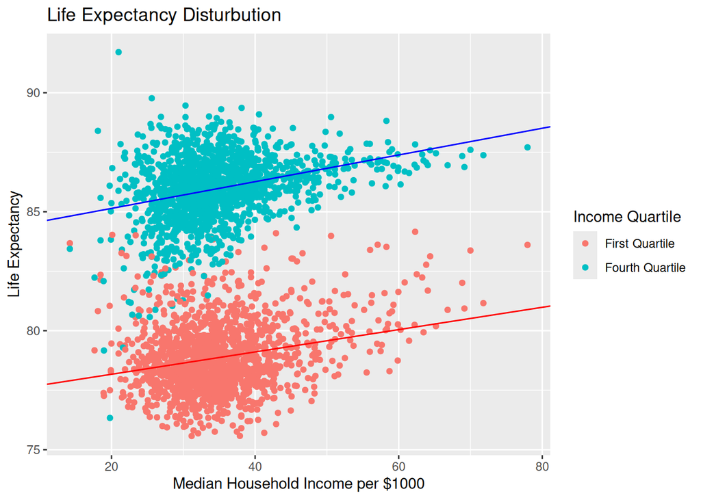

```r
ggplot(data= income) + geom_point(aes(x = median_hh_inc,
                                      y = life_exp,
                                      color = factor(
                                        income_quartile,
                                        labels = c("First Quartile", "Fourth Quartile")))) +
  labs(title = "Life Expectancy Disturbution",
    x = "Median Household Income per $1000",
    y = "Life Expectancy",
    color = "Income Quartile"
   ) +geom_abline(slope = 0.046904, intercept = 77.232936, color = "red") +

geom_abline(slope = 0.056132, intercept = 84.018910, color = "blue")
```

## 15.

For the population in the first quartile of income, we see that the predicted life expectancy for a person of 0 income is 77.23 years on average. For each $1000 increase in median income, we predict that the life expectancy will go up by 0.04 years.

For the fourth quartile, we see that the predicted life expectancy is 84.01 years old. For each $1000 increase in household income, we predict a 0.05 years increase in life expectancy.

The regression results show that there is a positive association between life expectancy and median household income for both quartile in income earners. While the intercept represents the life expectancy earning 0 dollars does not make sense, we can infer from it that being within the fourth quartile in income owner shows there is very little difference life expectancy compared to the first quartile where itt deviates by 0.01 years per additional $1000.

The model does not explain everything where there is a offset in life expectancy in those who earn the same amount but also happens to be in the fourth quartile, however it does suggests that a positive relationship exists between income and life expectancy (visually).

## 16.

```r
income$is_q4 = as.integer(income$income_quartile == 4)
#lm(life_exp ~ median_hh_inc + , data = (income_q1))
interaction_prediction = lm(life_exp ~ median_hh_inc + is_q4 + median_hh_inc :is_q4, data = income)

summary(interaction_prediction)
```

```
##
## Call:
## lm(formula = life_exp ~ median_hh_inc + is_q4 + median_hh_inc:is_q4,
##     data = income)
##
## Residuals:
##     Min      1Q  Median      3Q     Max
## -8.7940 -0.8340 -0.0642  0.8016  6.5114
##
## Coefficients:
##                      Estimate Std. Error t value Pr(>|t|)
## (Intercept)         77.232936   0.161700 477.632   <2e-16 ***
## median_hh_inc        0.046904   0.004536  10.340   <2e-16 ***
## is_q4                6.785974   0.228669  29.676   <2e-16 ***
## median_hh_inc:is_q4  0.009228   0.006414   1.439     0.15
## ---
## Signif. codes:  0 '***' 0.001 '**' 0.01 '*' 0.05 '.' 0.1 ' ' 1
##
## Residual standard error: 1.355 on 3102 degrees of freedom
## Multiple R-squared:  0.8746, Adjusted R-squared:  0.8745
## F-statistic:  7212 on 3 and 3102 DF,  p-value: < 2.2e-16
```

## 17.

- The intercept of the average life expectancy of a person making $0 is 77.23 years.
- The average median household income per $1000 increase is 0.04 additional years on the life span.
- If a person is within the fourth quartile in terms of median household income, then their life expectancy is predicted to increase by 6.78 years.
- The median_hh_inc:is_q4 says that there is basically no significant interactions between the median household income and being in the fourth quartile.

## 18.

The regression result in model [14] and [16] are generally the same in terms of slope and intercept. Model [14] regresses the two income quartile seperately, we see a intercept of 77.23 for Q1 and a intercept of 84.01 for Q4.

## 19.

The results in [16] does suggest an association between life expectancy and median household income. In the model, we regressed on the condition that being in the higher income quartile will increase life expectancy from the start. The binary condition of yes in Q4 or no in Q1 will determine how much the slope intercept will increase by if in Q4. This shows that on average, people who make the Q4 income quartiles will see a increase in life expectancy compared to those in the lower income quartiles.

## 20.

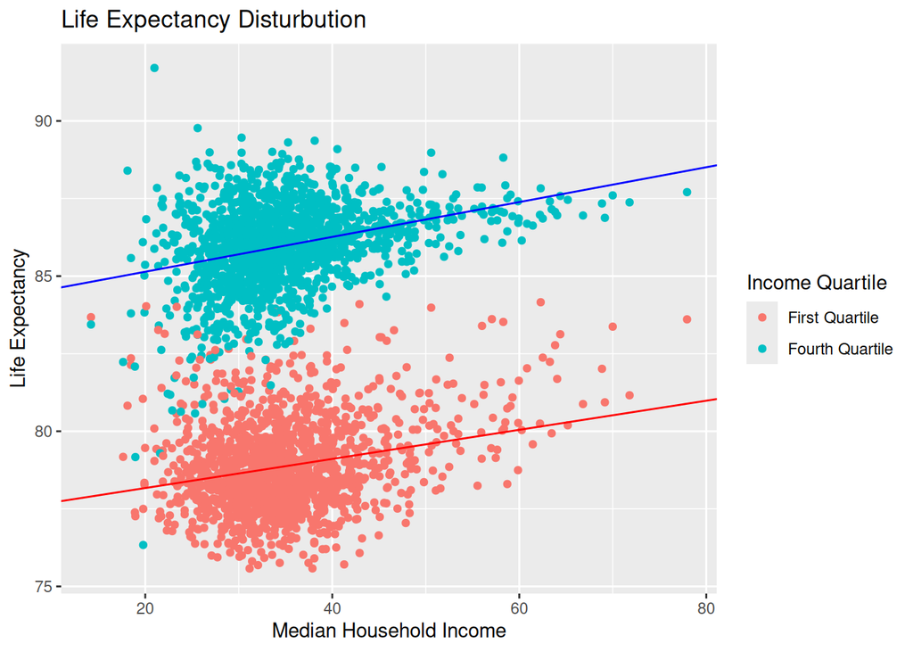

```r
ggplot(data= income) + geom_point(aes(x = median_hh_inc,
                                      y = life_exp,
                                      color = factor(
                                      income_quartile,
                                      labels = c("First Quartile", "Fourth Quartile")))) +
  labs(title = "Life Expectancy Disturbution",
    x = "Median Household Income",
    y = "Life Expectancy",
    color = "Income Quartile")+
    geom_abline(slope = 0.046904, intercept = 77.232936, color = "red") +
    geom_abline(slope = 0.056132, intercept = 84.018910, color = "blue")
```